# What Makes TikTok Advertisements Keep Attention?

## Introduction

TikTok advertisements appear constantly while users scroll through content, but not every advertisement receives the same level of attention. This project explores which types of advertisements are more successful at keeping viewers engaged.

The data was collected through observational logging while using TikTok. Each observation recorded the advertisement category, the amount of time spent watching the advertisement, how the advertisement was interacted with, and how interesting it appeared to be.

## Which Advertisement Categories Hold Attention?

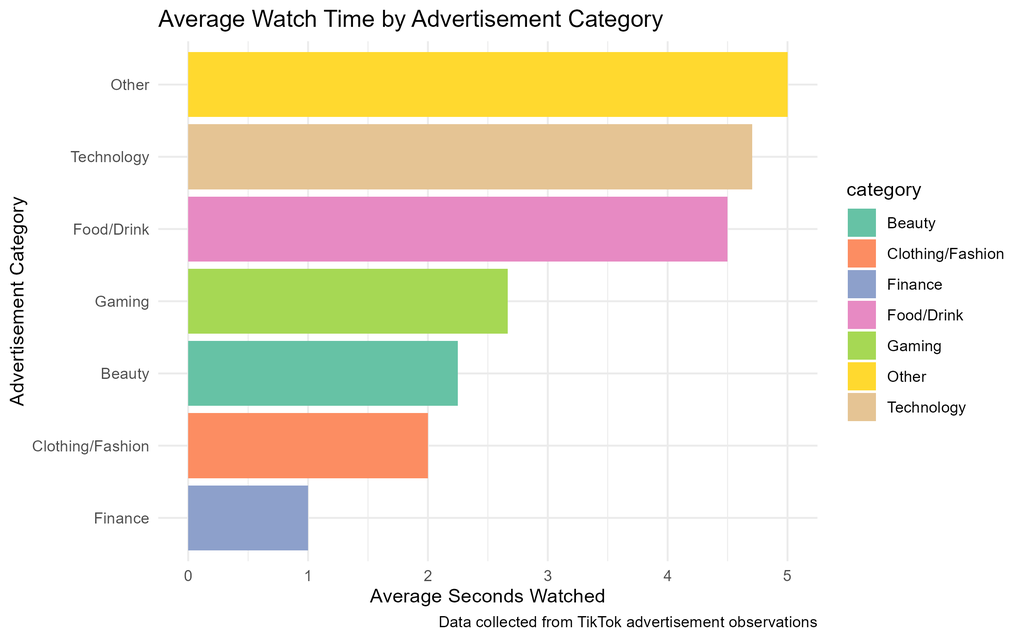

Bar chart showing average advertisement watch time across advertisement categories

This visualisation compares the average amount of time spent watching advertisements from different categories. Technology and food-related advertisements had some of the highest average watch times, while finance advertisements were skipped much more quickly.

This suggests that advertisement category may influence whether users continue watching advertisements on TikTok.

## Are Interesting Advertisements Watched Longer?

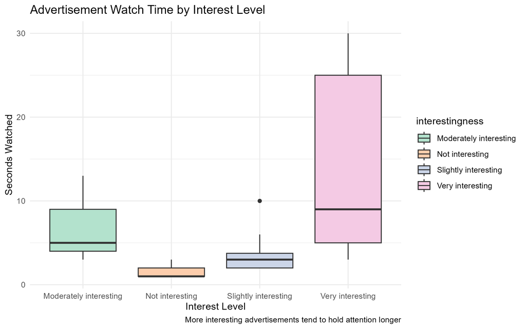

Boxplot showing the relationship between advertisement interest level and watch time

This boxplot shows a clear relationship between how interesting an advertisement was perceived to be and the amount of time spent watching it.

Advertisements rated as “Very interesting” generally had much higher watch times and greater variation, while advertisements rated as “Not interesting” were usually skipped quickly.

This suggests that viewer interest strongly affects engagement and retention.

## Advertisement Engagement Throughout the Day

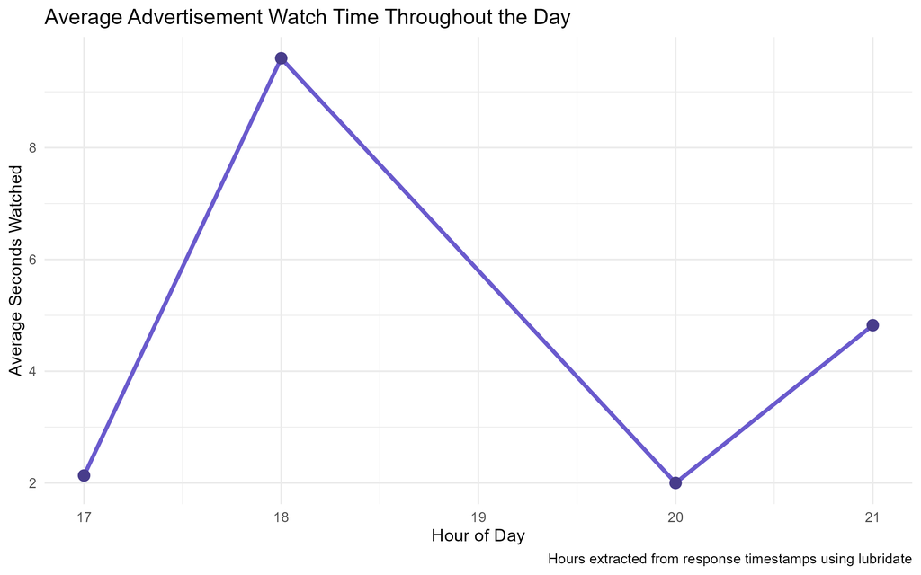

Line graph showing average advertisement watch time throughout the day

The final visualisation uses timestamps collected from the observations to examine how advertisement watch time changed throughout the day.

The graph shows fluctuations in average watch time depending on the hour. Some periods showed noticeably higher engagement levels than others.

Although the dataset is relatively small, the pattern suggests that time of day may influence user attention and willingness to engage with advertisements.

## Conclusion

Overall, the data suggests that TikTok advertisements are more successful when the viewer finds it interesting and belong to categories that naturally encourage viewer engagement. Advertisements that were less interesting were often skipped immediately, while engaging advertisements were watched for longer periods and sometimes encouraged further interaction.